# Whose Got Classe?

Mark A. Stephens

July 26, 2015

Final Project | Practical Machine Learning | Johns Hopkins Data Science Certification

# Summary

The goal of this project is to predict the manner in which participants in Human Activity Recognition study completed the exercise.

Completion of the exercise is defined in 5 classes:

- A exactly according to specification
- B throwing elbows to the front
- C lifting the dumbbell only halfway
- D lowering the dumbbell only halfway
- E throwing the hips to the front

A summary of the study and associated literature is accessible here: http://groupware.les.inf.puc-rio.br/har

Result of test data submission is 20/20 correct.

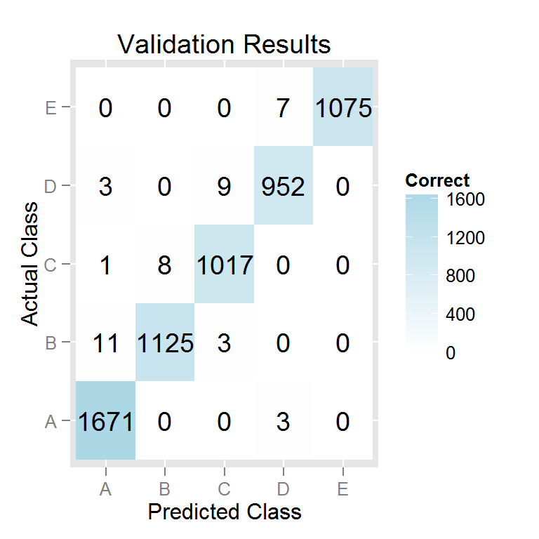

The Analysis section explains how the model was built (including a discussion of choices made throughout the process as well as how cross-validation is used when training the model) and a review of validation and testing. The Appendix includes the R script created to build, validate, and test the model.

# Analysis

### How the model was built

Steps in building the model are as follows:

1. Load and clean the data
2. Explore the data
3. Choose predictors
4. Split the data into training and validation sets
5. Train the model
6. Validate the model

The training dataset were loaded into the working directory from https://d396qusza40orc.cloudfront.net/predmachlearn/pml-training.csv

The data were inspected using Microsoft Excel. Based upon inspection, data with values of #DIV/0, NA, and blanks were set to NA. Variables with greater than 50% of NA values were removed.

The distribution of the outcome variable, Classe, was explored to understand the balance of the outcome by factor.

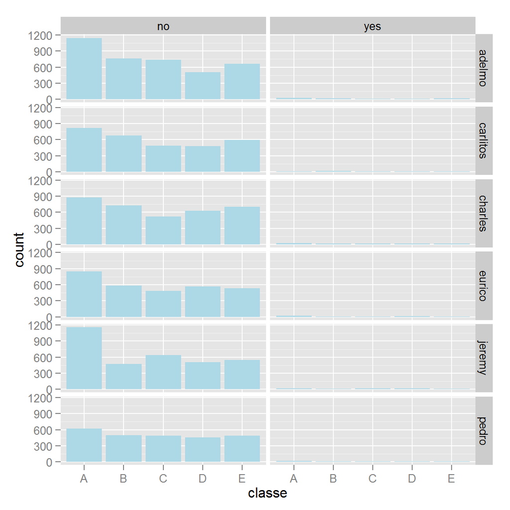

Of particular interest in exploration is the impact and relevance of variable new_window. Classe distributions by factor skew towards classe equal to A for all participants.

Predictors for model training were chosen by:

1. removing non zero variance variables
2. removing variables with linear dependencies
3. checking for highly correlated variables

[figure not shown]

Seventy percent of complete cases in the original training data were used to train the model.

The remaining thirty percent were used for validation.

The model was trained using random forest, rf method in the caret package. The environment used for training is as follows:

- Processor: Intel Core i7
- RAM: 16 GB
- R Version: R-3.2.1 64-bit
- Parallel processing allowed

The model was built using 5-fold cross validation based upon an outcome factor level of 5. Accuracy was chosen to select the optimal model.

The following is the outcome of the training process:

```
## Random Forest
##
## 13737 samples
##    46 predictor
##     5 classes: 'A', 'B', 'C', 'D', 'E'
##
## No pre-processing
## Resampling: Cross-Validated (5 fold)
## Summary of sample sizes: 10990, 10990, 10990, 10989, 10989
## Resampling results across tuning parameters:
##
##   mtry  Accuracy   Kappa      Accuracy SD  Kappa SD
##    2    0.9861685  0.9825013  0.003444679  0.004358630
##   24    0.9883523  0.9852648  0.002429797  0.003075037
##   46    0.9830382  0.9785420  0.002852119  0.003612568
##
## Accuracy was used to select the optimal model using  the largest value.
## The final value used for the model was mtry = 24.
```

The final model used for validation and testing is as follows:

```
##
## Call:
##  randomForest(x = x, y = y, mtry = param$mtry, proximity = TRUE,      allowParllel = TRUE)
##                Type of random forest: classification
##                      Number of trees: 500
## No. of variables tried at each split: 24
##
##         OOB estimate of  error rate: 0.79%
## Confusion matrix:
##      A    B    C    D    E class.error
## A 3895    3    2    5    1 0.002816180
## B   22 2621   14    1    0 0.013920241
## C    5   15 2375    1    0 0.008764608
## D    0    2   23 2225    2 0.011989343
## E    1    2    3    7 2512 0.005148515
```

### Model validation

The result of model validation is accuracy of 99.2%.

Therefore, the expected out of sample error rate is 0.8%.

Visual results of model validation are shown in the Summary section confusion matrix (see chart in Summary section). A detailed summary of validation is shown in the Appendix.

# Appendix

#### Validation Results

|  | Sensitivity | Specificity | Pos Pred Value | Neg Pred Value | Prevalence | Detection Rate | Detection Prevalence | Balanced Accuracy |
| --- | --- | --- | --- | --- | --- | --- | --- | --- |
| Class: A | 0.9982079 | 0.9964379 | 0.9911032 | 0.9992855 | 0.2844520 | 0.2839422 | 0.2864911 | 0.9973229 |
| Class: B | 0.9877085 | 0.9983144 | 0.9929391 | 0.9970539 | 0.1935429 | 0.1911640 | 0.1925234 | 0.9930114 |
| Class: C | 0.9912281 | 0.9975304 | 0.9883382 | 0.9981466 | 0.1743415 | 0.1728122 | 0.1748513 | 0.9943792 |
| Class: D | 0.9875519 | 0.9979679 | 0.9896050 | 0.9975625 | 0.1638063 | 0.1617672 | 0.1634664 | 0.9927599 |
| Class: E | 0.9935305 | 1.0000000 | 1.0000000 | 0.9985447 | 0.1838573 | 0.1826678 | 0.1826678 | 0.9967652 |

#### Validation Confusion Matrix

|  | A | B | C | D | E |
| --- | --- | --- | --- | --- | --- |
| A | 1671 | 11 | 1 | 3 | 0 |
| B | 0 | 1125 | 8 | 0 | 0 |
| C | 0 | 3 | 1017 | 9 | 0 |
| D | 3 | 0 | 0 | 952 | 7 |
| E | 0 | 0 | 0 | 0 | 1075 |

#### Validation Overall Statistics

| Accuracy | 0.9923534 |
| --- | --- |
| Kappa | 0.9903257 |
| AccuracyLower | 0.9897815 |
| AccuracyUpper | 0.9944172 |
| AccuracyNull | 0.2844520 |
| AccuracyPValue | 0.0000000 |
| McnemarPValue | NaN |

## R Script

#### Instructions for running script

```r
### Practical Machine Learning Project
### Human Activity Recognition
### Whose got Classe?
### Mark Stephens
### July 2015

# Human Activity Recognition study reference: http://groupware.les.inf.puc-rio.br/har
# Prediction outcome variable = classe (the manner in which they did the exercise)

# To reproduce the outcome :
# Source training data from: https://d396qusza40orc.cloudfront.net/predmachlearn/pml-training.csv
# Source test data from: https://d396qusza40orc.cloudfront.net/predmachlearn/pml-testing.csv
# Store training and test data in working directory
# Run the functions in the following order:
# loaddata
# check_missing
# ChoosePredictors (get_cor can be run to see if there are highly correlated variables)
# split_data
# remove_trash
# trainModel
# save_model (use read_model to reuse saved model)
# predictVal
# valResults
# createConfusion (use createGGConfusion to create plot of confusion matrix)
# loadtest
# predictTest
# convertTF
# submitanswers

# Review comments and code below for information about analysis and functions
```

#### R Script

```r
### Practical Machine Learning Project
### Human Activity Recognition
### Whose got Classe?
### Mark Stephens
### July 2015

## require packages
require(caret)
require(dplyr)
require(knitr)
require(som)


## Load training data
loaddata <- function(){

  ## Source training data from:
  ## Store training data in working directory

  ## read data from source file located in working directory
  training_full <<- read.csv(file = "pml-training.csv",na.strings = c('#DIV/0!','NA',''),stringsAsFactors = FALSE )
}

## Remove variables with > 50% missing data
check_missing <-function(){

  training_row <- nrow(training_full)

  col_is_bad <<- apply(training_full,2,function(col){

    sum(is.na(col)) / training_row > 0.5

  })

## Remove variables with > 50% values classified as missing data (is.na is true)

  training_full[col_is_bad] <<- list(NULL)

}


## Preprocess

get_pre <- function(){

  pretrain <<- preProcess(training_full[,c(-1,-2,-3,-4,-5,-6,-160)],method=c("center","scale"))

}

## Discover Data
plot_histogram <- function(){

  ## review distribution of outcomes (classe)

  g <- ggplot(data=training_full,aes(x=classe))

  g <- g + geom_histogram(fill = "lightblue")

  g <- g + facet_grid(user_name~new_window)

  g

}

### review summary of outcome distribution
get_summary <- function(){

  kable(summarize(group_by(training_full,user_name,new_window,classe),length(classe)))

}

## Preprocess Data
## http://topepo.github.io/caret/preprocess.html

## Choose Predictors
## Predictors for model training are chosen by:
## 1. removing non zero variance variables
## 2. removing variables with linear dependencies
## 3. A check for highly correlated variables is provided in function get_cor

## Use the function ChoosePredictors to create a vector of predictors to subset the training data
## ChoosePredictors function calls the find_linears and find_nzvs function

## Find & Remove Linear dependencies
find_linears <- function(){

  comboInfo <<- findLinearCombos(training_full[ ,trainpredictors])

  remove_linears <<- comboInfo$remove

  if(length(remove_linears) >= 1){trainpredictors <<- trainpredictors[-remove_linears]}

}


## Find Near Zero Variance Variables

## Use to identify predictors with potential to become zero-variance predictors when data are split into
## cross-validation/bootstrap sub-samples or that a few samples may have undue influence on the model.
## Identify NZVs and eliminate prior to modeling.

find_nzvs <- function(){

  nzvs <<- nearZeroVar(training_full,saveMetrics = TRUE)

  predictor_choice <<- nzvs[(nzvs$nzv==FALSE) & (nzvs$freqRatio < 10),  ]

  kable(predictor_choice)
}

## To choose predictors:
## Remove near zero variance variables (find_nzvs)
## El
ChoosePredictors <- function(){

  ## Eliminate non zero variables

  find_nzvs()

  trainpredictors <<- rownames(predictor_choice)

  ## Remove non numeric data

 remove_predictor <- c("X","user_name","raw_timestamp_part_1","raw_timestamp_part_2","raw_timestamp_part_3","cvtd_timestamp","num_window",
                       "classe")

 trainpredictors <<- trainpredictors[!trainpredictors %in% remove_predictor]



  find_linears()

}

## Review correlations to determine if there are highly correlated predictors
## Highly correlated predictors defined for variables with correlation >= 90

get_cor <- function(){

  ## create corrleation matrix of chosen predictor variables

  cor_vec <<- cor(training_full[ ,trainpredictors])

  ## Review correlated predictors

  cor_eliminate <<- findCorrelation(cor_vec, cutoff = 0.90, names = FALSE, exact = FALSE)

}

## Split data into training and validation
## Use 70% for training and 30% for validation

split_data <- function(){

  ## use only complete cases
  training <<- training_full[complete.cases(training_full) , trainpredictors ]

  ## add classe column to training data
  training <<- cbind(training,classe=training_full[ ,"classe"])


  ## use 70% of training data for training and 30% for validation

  set.seed(123456)

  inTrain <- createDataPartition(y=training$classe,p=0.7,list=FALSE)

  trainset <<- training[inTrain, ] ## create training set

  valset <<- training[-inTrain, ] ## create validation set

}

## Remove unneeded objects from memory to maximize memory available to train model

removetrash <- function(){

 ## rm(predictor_choice,envir=sys.frame(-1))
  rm(training,envir=sys.frame(-1))
  rm(training_full,envir=sys.frame(-1))
  rm(nzvs,envir=sys.frame(-1))

  gc()

}

## Train Model
## Train using Random Forest for accuracy using 5-fold cross validation

## System parameters are
## Processor: Intel Core i7
## RAM: 16 GB
## R Version: R-3.2.1 64-bit
## Parallel processing allowed

trainModel <- function(){

## Train using Random Forest for accuracy using 5-fold cross validation
## 5 classes of outcome so K = 5 for K-fold cross-validation

rf_model <<- train(as.factor(classe) ~., data = trainset ,method="rf",
                   metric="Accuracy",
                   trControl=trainControl(method="cv",number=5),
                   prox=TRUE,allowParllel=TRUE)

}

## Save training model for reuse
## Training model saved in working directory
save_model <- function(){

  saveRDS(rf_model,file="rf_model1.rds")
}

## Read training model
read_model <- function(){

  rf_model <<- readRDS("rf_model1.rds")

}

## Validate Model
## Use 30% of data from training source file for validation
predictVal <- function(){

  testfit <<- predict(rf_model,newdata=valset)

}

### Get results
valResults <- function(){

  valResult <<- table(testfit,valset$classe)
}

## Create Confusion Matrix
createConfusion <- function(){

  cfMatrix <<- confusionMatrix(valResult)
}

## Create ggplot Confusion Matrix
createGGConfusion <- function(){

  cdata <<- as.data.frame(cfMatrix$table)

  g <- ggplot(cdata)

  g <- g + geom_tile(aes(x=testfit,y=Var2,fill=Freq))

  g <- g + geom_text(aes(x=testfit,y=Var2,fill=Freq),label = cdata$Freq)

  g <- g + labs(fill = "Correct" , x = "Predicted Class", y = "Actual Class")

  g <- g + scale_fill_gradient(low = "white", high = "lightblue")

  g <- g + ggtitle("Validation Results")

  g

}

## Test Model

## Load Test Data
## Source test data from:
## Load test data into working directory
## Define missing data per training data definition

loadtest <- function(){

  test_data <<- read.csv(file = "pml-testing.csv",na.strings = c('#DIV/0!','NA',''),stringsAsFactors = FALSE )

}

## Predict on testing data

predictTest <- function(){

  testfit <<- predict(rf_model,newdata=test_data)
}

## Convert test fit to character vector for submission
convertTF <- function(){

  testsubmit <<- as.character(testfit)

}

## Create Submission

pml_write_files = function(x){

  n = length(x)

  for(i in 1:n){

    filename = paste0("problem_id_",i,".txt")

    write.table(x[i],file=filename,quote=FALSE,row.names=FALSE,col.names=FALSE)

  }
}

submitanswers <- function(){

  pml_write_files(testsubmit)

}

## Show Importance of variables in final model
showImportance <- function(){

  sI <<- as.data.frame(rf_model$finalModel$importance)

  sI <<- cbind(rownames(sI),sI)

  colnames(sI) <<- c("Variable","MeanDecreaseGini")

  rownames(sI) <<- NULL

  g <- ggplot(sI, aes(x=factor(Variable),y=MeanDecreaseGini))

  g <- g + geom_bar(stat = "identity")

  g <- g + theme(axis.text.x = element_text(angle = 90))

  g <- g + xlab("Predictor (order of importance)")

  g <- g + ylab(" Mean Decrease Gini")

  g <- g + ggtitle("Chosen Predictors & Importance")
  g
}

## Show Chosen Model Accuracy
model_Accuracy <- function(){
  paste0(round(rf_model$results$Accuracy[2]*100,1),"%")
}

### Show training model
show_train_model <- function(){

  rf_model
}

### Show final model
show_final_model <- function(){

  rf_model$finalModel

}

### Show validation accuracy
val_Accuracy <- function(){

paste0(round(cfMatrix$overall[1]*100,1),"%")

}

### Show out of sample error
oos_Error <- function(){

    paste0(round((1-cfMatrix$overall[1])*100,1),"%")
}
```